# Water Cycling Graphical Summary

## Introduction

This is a notebook to make some summary plots for the Water Cycling Team to share with Jason Rowntree on 3/20/23

## Datasets

First load the zentra files that were manually downloaded from ZentraCloud (entire record)

```
## [1] "z6-18342"
## [1] "z6-18337"
## [1] "z6-18269"
## [1] "z6-18268"
## [1] "z6-18377"
## [1] "z6-18390"
## [1] "z6-19066"
## [1] "z6-19075"
```

```
##     Logger            datetime Site Treatment Block              sensor
## 1 z6-18342 2022-06-28 10:00:00   CR        AD     1 m3.m3.Water.Content
## 2 z6-18342 2022-06-28 11:00:00   CR        AD     1 m3.m3.Water.Content
## 3 z6-18342 2022-06-28 12:00:00   CR        AD     1 m3.m3.Water.Content
## 4 z6-18342 2022-06-28 13:00:00   CR        AD     1 m3.m3.Water.Content
## 5 z6-18342 2022-06-28 14:00:00   CR        AD     1 m3.m3.Water.Content
## 6 z6-18342 2022-06-28 15:00:00   CR        AD     1 m3.m3.Water.Content
##   water content
## 1         0.213
## 2         0.213
## 3         0.213
## 4         0.213
## 5         0.213
## 6         0.213
```

Next, load all of the zentra data available through the API (July-November)

```
##                             X timestamp_utc                  datetime tz_offset
## all_20220706_20220904.csv.1 0    1662271200 2022-09-04 00:00:00-06:00    -21600
## all_20220706_20220904.csv.2 1    1662270300 2022-09-03 23:45:00-06:00    -21600
## all_20220706_20220904.csv.3 2    1662269400 2022-09-03 23:30:00-06:00    -21600
## all_20220706_20220904.csv.4 3    1662268500 2022-09-03 23:15:00-06:00    -21600
## all_20220706_20220904.csv.5 4    1662267600 2022-09-03 23:00:00-06:00    -21600
## all_20220706_20220904.csv.6 5    1662266700 2022-09-03 22:45:00-06:00    -21600
##                             value Port Site         datetimeUTC        Name
## all_20220706_20220904.csv.1 0.098    3   WY 2022-09-04 06:00:00 WY_PR-14-12
## all_20220706_20220904.csv.2 0.098    3   WY 2022-09-04 05:45:00 WY_PR-14-12
## all_20220706_20220904.csv.3 0.098    3   WY 2022-09-04 05:30:00 WY_PR-14-12
## all_20220706_20220904.csv.4 0.098    3   WY 2022-09-04 05:15:00 WY_PR-14-12
## all_20220706_20220904.csv.5 0.098    3   WY 2022-09-04 05:00:00 WY_PR-14-12
## all_20220706_20220904.csv.6 0.098    3   WY 2022-09-04 04:45:00 WY_PR-14-12
##                             Treatment Block Triangle
## all_20220706_20220904.csv.1        PR    14       12
## all_20220706_20220904.csv.2        PR    14       12
## all_20220706_20220904.csv.3        PR    14       12
## all_20220706_20220904.csv.4        PR    14       12
## all_20220706_20220904.csv.5        PR    14       12
## all_20220706_20220904.csv.6        PR    14       12
```

```
##                                X timestamp_utc                  datetime
## all_WL_20220706_20220904.csv.1 0    1662264000 2022-09-04 00:00:00-04:00
## all_WL_20220706_20220904.csv.2 1    1662260400 2022-09-03 23:00:00-04:00
## all_WL_20220706_20220904.csv.3 2    1662256800 2022-09-03 22:00:00-04:00
## all_WL_20220706_20220904.csv.4 3    1662253200 2022-09-03 21:00:00-04:00
## all_WL_20220706_20220904.csv.5 4    1662249600 2022-09-03 20:00:00-04:00
## all_WL_20220706_20220904.csv.6 5    1662246000 2022-09-03 19:00:00-04:00
##                                tz_offset value Port Site         datetimeUTC
## all_WL_20220706_20220904.csv.1    -14400     5    4   MI 2022-09-04 04:00:00
## all_WL_20220706_20220904.csv.2    -14400     5    4   MI 2022-09-04 03:00:00
## all_WL_20220706_20220904.csv.3    -14400     5    4   MI 2022-09-04 02:00:00
## all_WL_20220706_20220904.csv.4    -14400     5    4   MI 2022-09-04 01:00:00
## all_WL_20220706_20220904.csv.5    -14400     6    4   MI 2022-09-04 00:00:00
## all_WL_20220706_20220904.csv.6    -14400     6    4   MI 2022-09-03 23:00:00
##                                      Name Treatment Block Triangle
## all_WL_20220706_20220904.csv.1 MI-PR_9_11        PR     9       11
## all_WL_20220706_20220904.csv.2 MI-PR_9_11        PR     9       11
## all_WL_20220706_20220904.csv.3 MI-PR_9_11        PR     9       11
## all_WL_20220706_20220904.csv.4 MI-PR_9_11        PR     9       11
## all_WL_20220706_20220904.csv.5 MI-PR_9_11        PR     9       11
## all_WL_20220706_20220904.csv.6 MI-PR_9_11        PR     9       11
```

Load the weather data for Lake City and convert the datetime object

```
##       date atmp_max atmp_min pcpn soil0_max soil0_min    srad   datetime
## 1 3/1/2022      1.0    -10.4 1.27       0.8       0.0  6342.4 2022-03-01
## 2 3/2/2022     -0.4    -14.3 0.25       0.2       0.0  5168.1 2022-03-02
## 3 3/3/2022     -2.5    -17.6 0.00       0.7      -0.1 13899.7 2022-03-03
## 4 3/4/2022      5.8    -18.4 0.00       1.2      -0.1 13898.0 2022-03-04
## 5 3/5/2022      6.2     -2.2 3.81       5.3       0.1  8038.4 2022-03-05
## 6 3/6/2022      9.7     -1.1 4.83      16.9      -0.1  1547.5 2022-03-06
```

Load the combined infiltration data and remove outliers

```
##   Year site ecotype block_name pasture_number treatment triangle     Record_ID
## 1   22   MI Pasture          7             NA        AD       10 22-MI-AD-7-10
## 2   22   MI Pasture          7             NA        AD        6  22-MI-AD-7-6
## 3   22   MI Pasture          7             NA        AD       11 22-MI-AD-7-11
## 4   22   MI Pasture          8             NA        AD        1  22-MI-AD-8-1
## 5   22   MI Pasture          8             NA        AD        4  22-MI-AD-8-4
## 6   22   MI Pasture          8             NA        AD        6  22-MI-AD-8-6
##               Date Kfs.1..cm.hr Kfs.2..cm.hr Kfs.3..cm.hr   Err.1     Err.2
## 1 10/20/2022 15:56     11.87640      32.0904           NA 7.80120   1.10268
## 2 10/20/2022 16:12      6.39720       8.9856       7.0164 0.24768   0.40464
## 3 10/20/2022 17:27      2.67156      19.6308           NA 0.13464   0.87120
## 4 10/20/2022 12:16      7.14240           NA           NA 0.74916   3.67200
## 5 10/20/2022 13:24     17.88120           NA      17.5356 0.44712  14.03640
## 6 10/20/2022 13:51     32.78520           NA           NA 1.09548 349.88400
##     Err.3 Season
## 1 30.0384   Fall
## 2 0.21132   Fall
## 3    <NA>   Fall
## 4 106.884   Fall
## 5  2.3454   Fall
## 6    <NA>   Fall
```

## Graphics

### Water Content Data

Plot all of the water content data for the first four months of deployment

- Note that Wyoming sensors were not deployed until September 2022
- In Michigan and Oklahoma, sensors are at 15, 40 and 60 cm depths
- In Wyoming there are at 10, 20, 30 cm due to difficulties augering into the rocky soil
- We observe that the wetter climate of Michigan makes the water content more dynamic
- Water content is quite variable between triangles at the same sites
- No discernable differences between the two treatments at this point

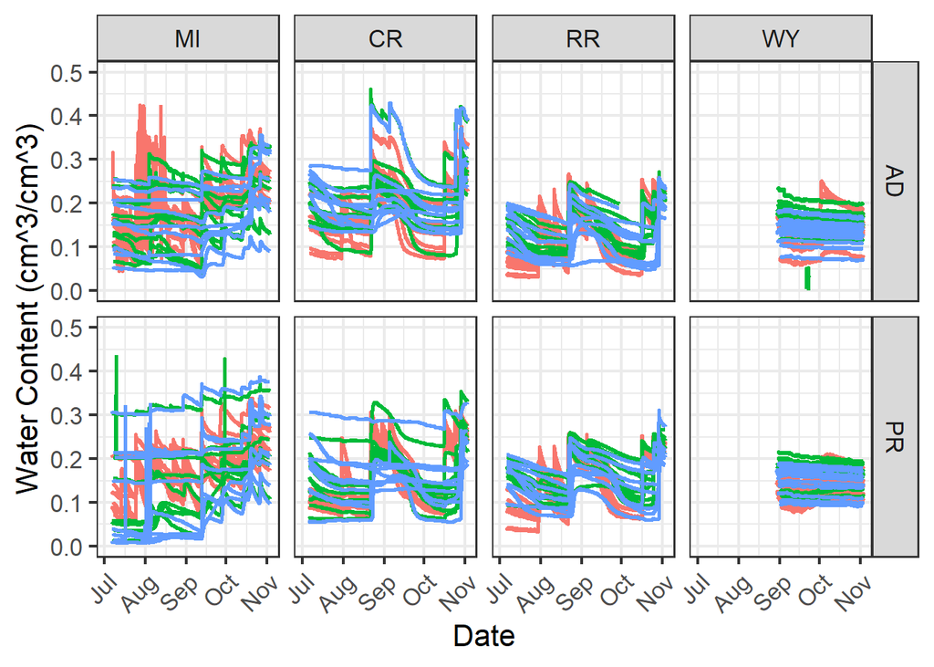

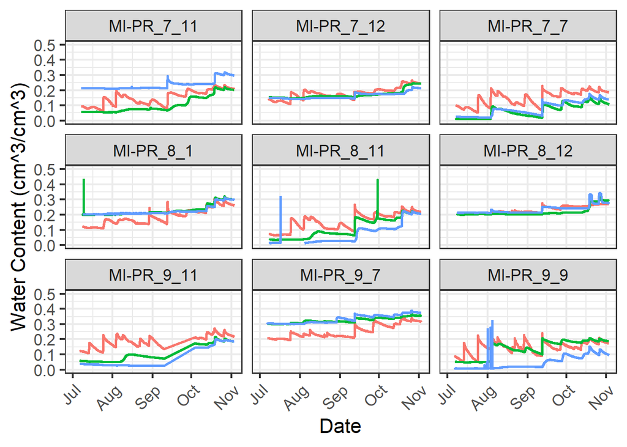

- Replot without the noisy data

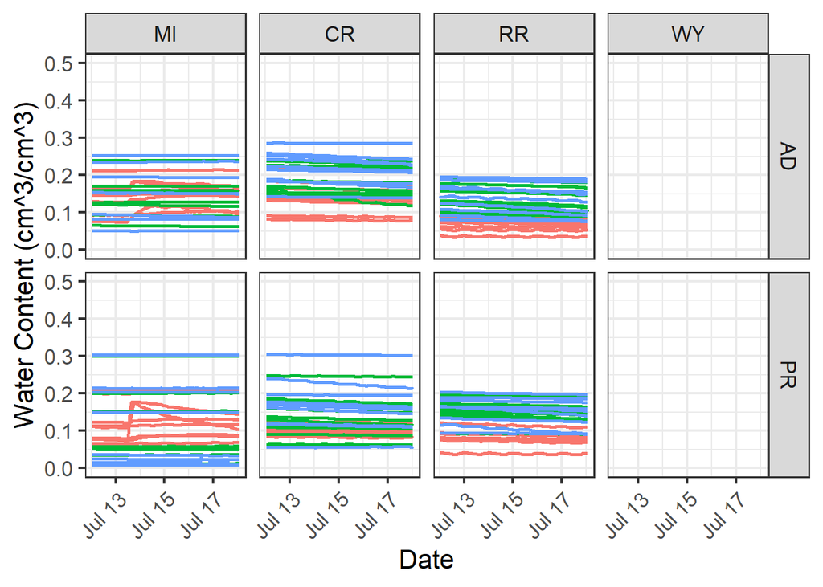

Do some summary statistics and average each logger through time for each site/treatment pair

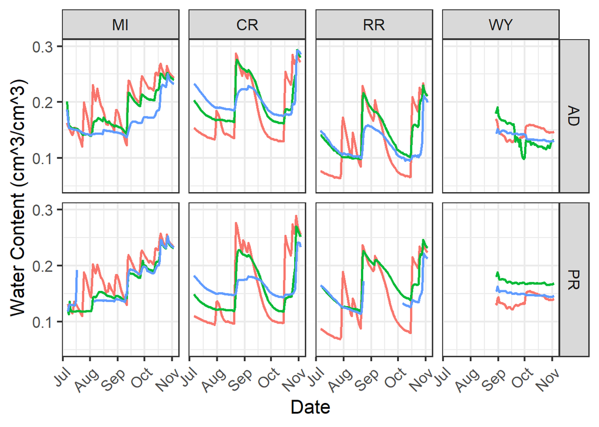

```r
zentra_WC_clean$day <- date(zentra_WC_clean$datetimeUTC)
zentra_WC_average <- zentra_WC_clean %>% group_by(Site, Treatment, Port, day) %>% summarise(avg_WC = mean(value))
p4 <- ggplot() + geom_line(data = zentra_WC_average,
      aes(x = day, y = avg_WC, group = as.factor(Port), color = as.factor(Port)),
      linewidth = 1, show.legend = FALSE) +
      theme_bw(base_size = 16) +
      theme(axis.text.x = element_text(angle = 45, hjust = 1)) +
      xlab("Date") + ylab("Water Content (cm^3/cm^3)") +
      ylim(c(0.05, 0.3)) + facet_grid(Treatment ~ factor(Site, levels = c("MI", "CR", "RR", "WY")))
p4
```

Look at one Logger from a selection of Site/Treatment pairs

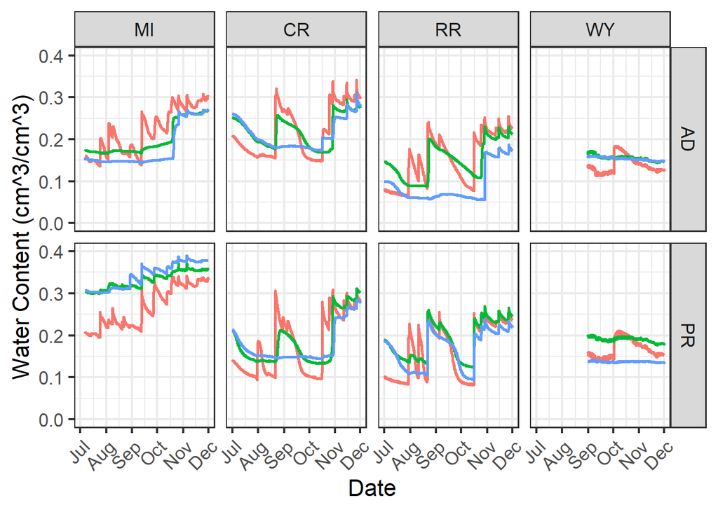

### Water Content at MI adaptive plot 9 with precip data (units are tenths of cm), July-Nov

- Note increases in soil water content correspond largely with large (> 10 mm) rain events
- Water content increases when ET decreases after the growing season (~October)

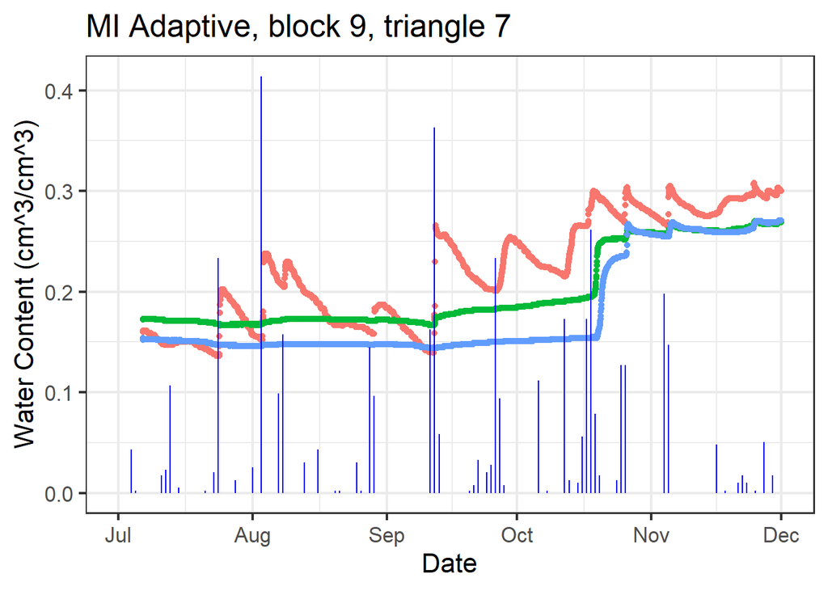

### Water level data in Michigan

Plot data grouped by treatment

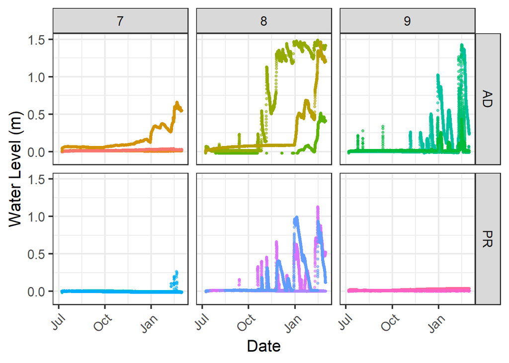

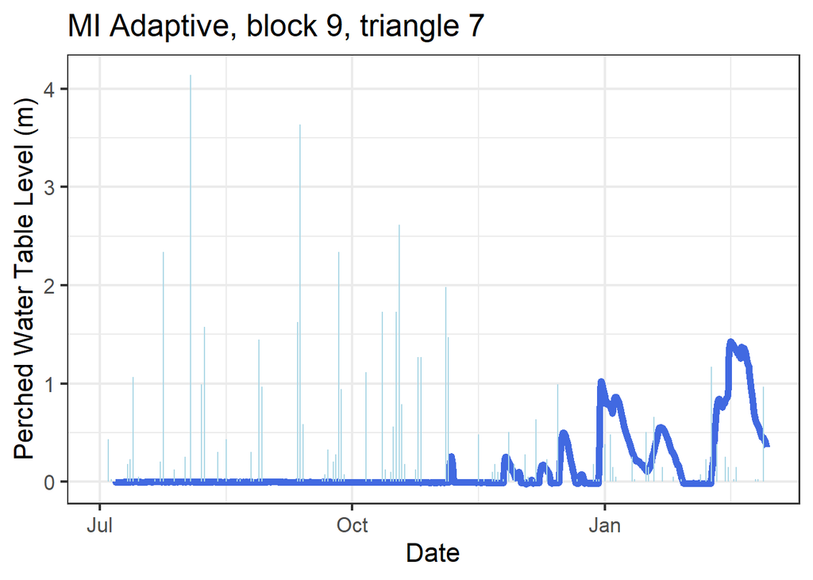

### Initial infilitration experiment results, grouped by treatment and state

- values outside the 5th and 95th percentile were filtered out
- measurements span February to November 2022, depending on site
- note the much higher values in Michigan and the large variability in measurements

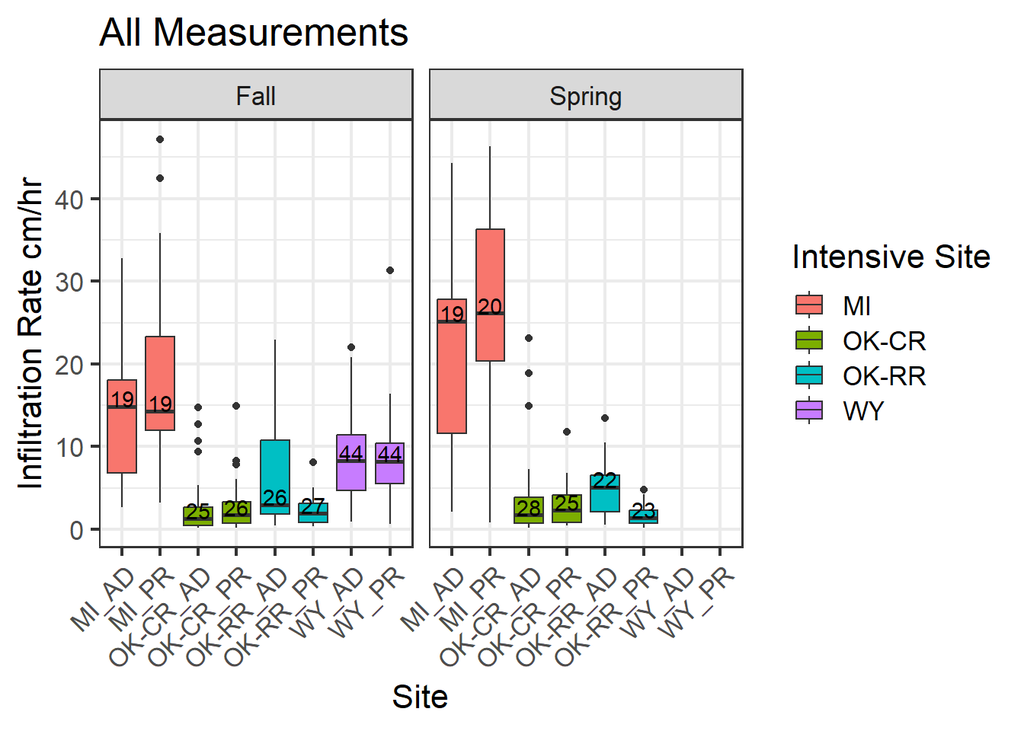

- Note the large variability even within a single ~1 m wide triangle within the same treatment

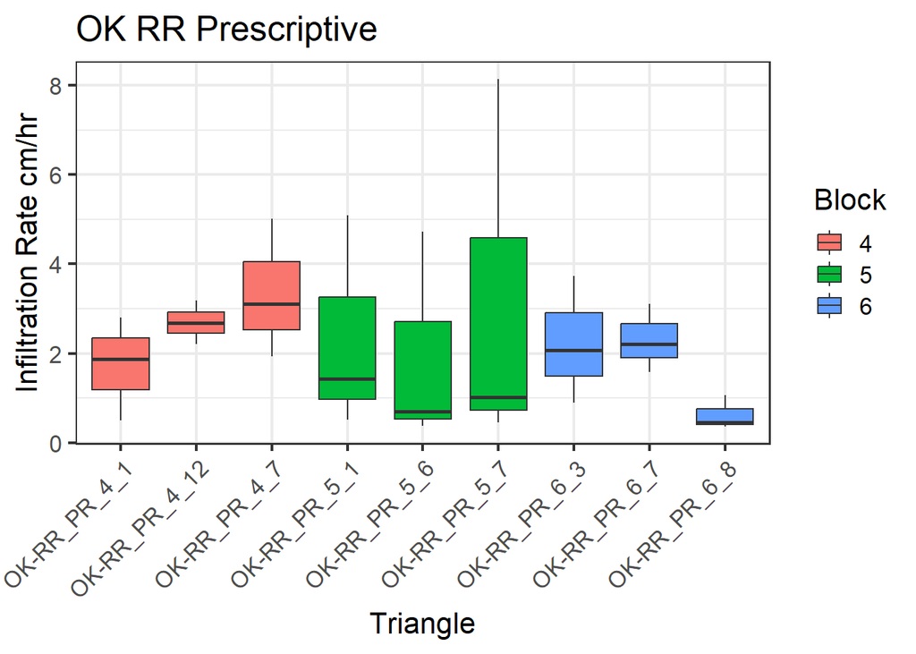